# R Markdown Tutorial

Alicia Halhed

09/18/2019

# What is R Markdown?

- R Markdown is a dynamic interface to **create reports** in R
- Available directly in RStudio
- Uses a simple syntax to format exported reports
- More information at rmarkdown.rstudio.com

# Why should I work in R Markdown when R Script works just fine?

- Allows the export of R workspaces to various file formats (Word, HTML, PDF, etc)
- Helps keep code organized in the R workspace
- Simplifies writing explanations of methods used in R

# Getting Started in R Markdown

[figure not shown]

[figure not shown]

# Working in R Markdown

- Writing scripts in R Markdown is very similar to working with an R Script.
- R code gets embedded into “chunks” in the R markdown file that can be formatted to your export needs.
  - Each chunk is formatted individually, so we can change the output based on what we are coding
- There are keyboard shortcuts for inserting code chunks
  - Mac users: control-option-i **or** command-option-i
  - PC users: control-alt-i
- Chunks of other coding languages (bash, SQL, Python, etc) can also be inserted into the same R Markdown file

#### Chunk in R Markdown (not exported)

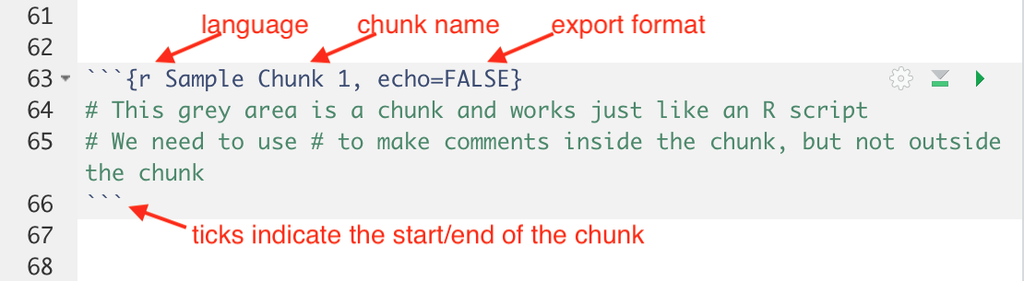

#### Chunk in R Markdown (exported)

```r
# This is what an exported code chunk looks like
data("mtcars")
```

#### Chunk in R Markdown (exported with output)

```r
head(mtcars)
```

```
##                    mpg cyl disp  hp drat    wt  qsec vs am gear carb
## Mazda RX4         21.0   6  160 110 3.90 2.620 16.46  0  1    4    4
## Mazda RX4 Wag     21.0   6  160 110 3.90 2.875 17.02  0  1    4    4
## Datsun 710        22.8   4  108  93 3.85 2.320 18.61  1  1    4    1
## Hornet 4 Drive    21.4   6  258 110 3.08 3.215 19.44  1  0    3    1
## Hornet Sportabout 18.7   8  360 175 3.15 3.440 17.02  0  0    3    2
## Valiant           18.1   6  225 105 2.76 3.460 20.22  1  0    3    1
```

#### Plots in R Markdown

- Plots, as with other R outputs, will appear below the code chunk where code is located
  - This applies to both the R workspace and the knit file
- Can specify in the chunk header whether or not to include the code in the knit file

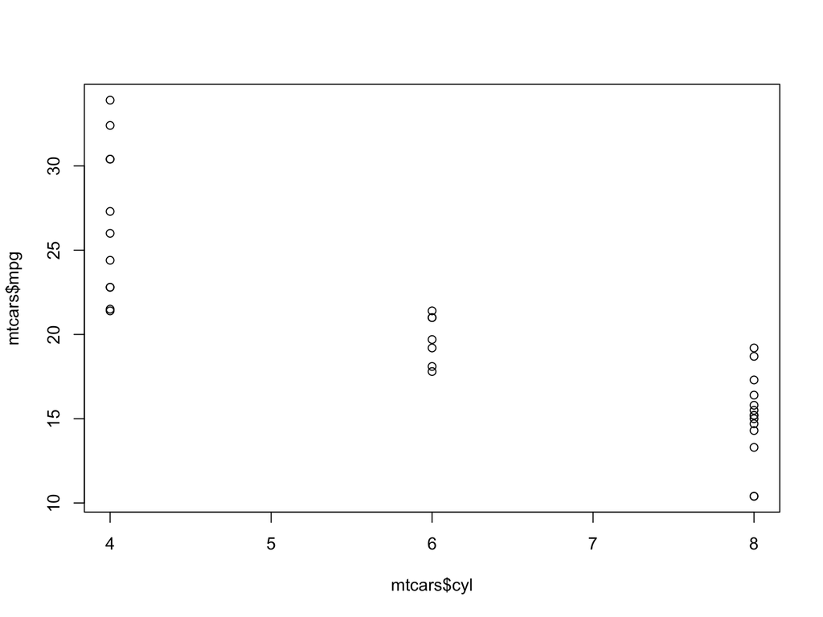

```r
plot(mtcars$mpg~mtcars$cyl)
```

#### Inline coding

- If you would like to include R outputs within the knit text, inline coding may be an option
- What is the product of 2<sup>2</sup>?
  - The answer is 4
- Simply typing the answer is possible, but coding it in simplifies creating the report for more complex problems

# Final thoughts